# CELLO-Seq Sarlacc pipeline - sample demultiplex

Rebecca Berrens, Andrian Yang, Aaron Lun, Florian Bieberich

24 January 2025

# 1 Introduction

This series of Rmarkdown files forms the CELLO-Seq sarlacc data processing pipeline, which utilises the `sarlacc` R package as its base.

After the initial quality control, we perform demultiplexing of reads using the sample barcodes.

# 2 Setting up sequence data

First, we define CELLO-seq adaptor sequences that should be present on each end of the read sequences.

Here, adaptor 1 represent the splint oligo containing the sample barcode (represented by a strech of `N`s) and the UMI (represented by a stretch of `NRY`s). We also have adaptor 2, which is the TSO adapter.

```r
adaptor1 <- "GTCTCGTGGGCTCGGAGATGTGTATAAGAGACAGNNNNNNNNNNNNNNNNNNNNNNNNAGTGGTATCNRYNRYNRYNRYNRYNRYNRYNRYNRYNRYNRYNRYNRYNRYNRYNRYNRYACTGGCCGTCGTTTTACATGGCGTAGCGGGTTCGAGCGCACCGCAGGGTATCCGGCTATTTTTTTTTTTTTTT"
adaptor2 <- "ACACTCTTTCCTCGTCGGCAGCGTCAGATGTGTATAAGAGAC"
```

We then define the barcode sequences that could be present in the first stretch of `N`s in `adaptor1`.

Here, we have included the 96 barcode sequences from ONT, though it is recommended that you include only the barcode used in the experiment.

```r
all.barcodes <- c("AAGAAAGTTGTCGGTGTCTTTGTG", "TCGATTCCGTTTGTAGTCGTCTGT", "GAGTCTTGTGTCCCAGTTACCAGG", "TTCGGATTCTATCGTGTTTCCCTA", "CTTGTCCAGGGTTTGTGTAACCTT", "TTCTCGCAAAGGCAGAAAGTAGTC", "GTGTTACCGTGGGAATGAATCCTT", "TTCAGGGAACAAACCAAGTTACGT", "AACTAGGCACAGCGAGTCTTGGTT", "AAGCGTTGAAACCTTTGTCCTCTC", "GTTTCATCTATCGGAGGGAATGGA", "CAGGTAGAAAGAAGCAGAATCGGA", "AACGAGTCTCTTGGGACCCATAGA", "AGAACGACTTCCATACTCGTGTGA", "AGGTCTACCTCGCTAACACCACTG", "CGTCAACTGACAGTGGTTCGTACT", "ACCCTCCAGGAAAGTACCTCTGAT", "CCAAACCCAACAACCTAGATAGGC", "GTTCCTCGTGCAGTGTCAAGAGAT", "GAGCCTCTCATTGTCCGTTCTCTA", "TTGCGTCCTGTTACGAGAACTCAT", "ACCACTGCCATGTATCAAAGTACG", "CTTACTACCCAGTGAACCTCCTCG", "GCATAGTTCTGCATGATGGGTTAG", "GTAAGTTGGGTATGCAACGCAATG", "CATACAGCGACTACGCATTCTCAT", "CGACGGTTAGATTCACCTCTTACA", "TGAAACCTAAGAAGGCACCGTATC", "CTAGACACCTTGGGTTGACAGACC", "TCAGTGAGGATCTACTTCGACCCA", "TGCGTACAGCAATCAGTTACATTG", "CCAGTAGAAGTCCGACAACGTCAT", "CAGACTTGGTACGGTTGGGTAACT", "GGACGAAGAACTCAAGTCAAAGGC", "CTACTTACGAAGCTGAGGGACTGC", "ATGTCCCAGTTAGAGGAGGAAACA", "GCTTGCGATTGATGCTTAGTATCA", "ACCACAGGAGGACGATACAGAGAA", "CCACAGTGTCAACTAGAGCCTCTC", "TAGTTTGGATGACCAAGGATAGCC", "GGAGTTCGTCCAGAGAAGTACACG", "CTACGTGTAAGGCATACCTGCCAG", "CTTTCGTTGTTGACTCGACGGTAG", "AGTAGAAAGGGTTCCTTCCCACTC", "GATCCAACAGAGATGCCTTCAGTG", "GCTGTGTTCCACTTCATTCTCCTG", "GTGCAACTTTCCCACAGGTAGTTC", "CATCTGGAACGTGGTACACCTGTA", "ACTGGTGCAGCTTTGAACATCTAG", "ATGGACTTTGGTAACTTCCTGCGT", "GTTGAATGAGCCTACTGGGTCCTC", "TGAGAGACAAGATTGTTCGTGGAC", "AGATTCAGACCGTCTCATGCAAAGC", "CAAGAGCTTTGACTAAGGAGCATG", "TGGAAGATGAGACCCTGATCTACG", "TCACTACTCAACAGGTGGCATGAA", "GCTAGGTCAATCTCCTTCGGAAGT", "CAGGTTACTCCTCCGTGAGTCTGA", "TCAATCAAGAAGGGAAAGCAAGGT", "CATGTTCAACCAAGGCTTCTATGG", "AGAGGGTACTATGTGCCTCAACGC", "CACCCACACTTACTTCAGGACGTA", "TTCTGAAGTTCCTGGGTCTTGAAC", "GACAGACACCGTTCATCGACTTTC", "TTCTCAGTCTTCCTCCAGACAAGG", "CCGATCCTTGTGGCTTCTAACTTC", "GTTTGTCATACTCGTGTGCTCACC", "GAATCTAAGCAAACACGAAGGTGG", "TACAGTCCGAGCCTCATGTGATCT", "ACCGAGATCCTACGAATGGAGTGT", "CCTGGGAGCATCAGGTAGTAACAG", "TAGCTGACTGTCTTCCATACCGAC", "AAGAAACAGGATGACAGAACCCTC", "TACAAGCATCCCAACACTTCCACT", "GACCATTGTGATGAACCCTGTTGT", "ATGCTTGTTACATCAACCCTGGAC", "CGACCTGTTTCTCAGGGATACAAC", "AACAACCGAACCTTTGAATCAGAA", "TCTCGGAGATAGTTCTCACTGCTG", "CGGATGAACATAGGATAGCGATTC", "CCTCATCTTGTGAAGTTGTTTCGG", "ACGGTATGTCGAGTTCCAGGACTA", "TGGCTTGATCTAGGTAAGGTCGAA", "GTAGTGGACCTAGAACCTGTGCCA", "AACGGAGGAGTTAGTTGGATGATC", "AGGTGATCCCAACAAGCGTAAGTA", "TACATGCTCCTGTTGTTAGGGAGG", "TCTTCTACTACCGATCCGAAGCAG", "ACAGCATCAATGTTTGGCTAGTTG", "GATGTAGAGGGTACGGTTTGAGGC", "GGCTCCATAGGAACTCACGCTACT", "TTGTGAGTGGAAAGATACAGGACC", "AGTTTCCATCACTTCAGACTTGGG", "GATTGTCCTCAAACTGCCACCTAC", "CCTGTCTGGAAGAAGAATGGACTT", "CTGAACGGTCATAGAGTCCACCAT")
```

# 3 Alignment of adaptor

We now align the adaptor sequences to all of the reads using sarlacc’s `adaptorAlign` function.

We are using fixed parameters for gapOpening and gapExtension chosen from one run of the `tuning.Rmd` file. We could also supply the tuned parameters directly but will not do so for simplicity.

By default, the alignment will only consider the 250 bp on either end of the read to reduce the runtime, under the assumption that the adaptors should occur at the read ends. This can be further sped up by parallelising jobs using the `BiocParallel` package with the appropriate backend supplied to the optional `BPPARAM=` argument.

```r
aln.out <- adaptorAlign(adaptor1, adaptor2, filepath=params$fastq_file, gapOpening=8, gapExtension=3, BPPARAM=multicoreParam)
colnames(aln.out)
```

```
## [1] "read.width" "adaptor1"   "adaptor2"   "reversed"
```

The output is a `DataFrame` that contains alignment information for each adaptor. For example, the `adaptor1` field contains a nested `DataFrame` with alignment scores and positions for `adaptor1` on the read:

```r
aln.out$adaptor1
```

[output not shown]

[output cut: 38 more lines]

Note that the positions here refer to coordinates on a “canonical orientation” of the read where the adaptor 1 occurs at the 5’ end. Reads are marked as being reverse-complemented (if necessary) to match this canonical orientation, to ensure that adaptor 1 and 2 are located on the 5’ and 3’ ends respectively.

Whether or not a read sequence was reverse-complemented is indicated by the `aln.out$reversed` field:

```r
summary(aln.out$reversed)
```

```
##    Mode   FALSE    TRUE
## logical    3840    3379
```

# 4 Filtering for adaptor-containing reads

We now use sarlacc’s `getAdaptorThresholds` function to choose an appropriate score threshold for the presence of an adaptor. This involves scrambling the start and end sequences, and repeating the alignment, with the aim of choosing a threshold that distinguishes between the real and scrambled scores.

To expedite this process, we only perform this for a random set of 10000 reads.

```r
N <- min(10000, nrow(aln.out))
subset <- aln.out[sample(nrow(aln.out), N),]
thresh <- getAdaptorThresholds(subset)
thresh$threshold1
```

```
## [1] -66.03489
```

```r
thresh$threshold2
```

```
## [1] -22.31985
```

We verify that the thresholds are suitable for adaptor 1:

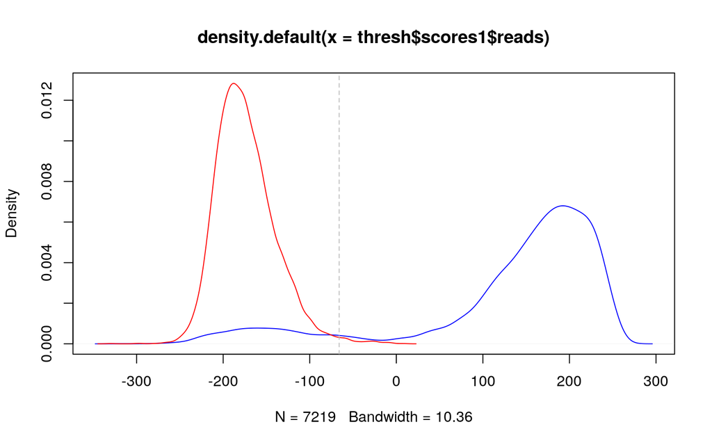

Figure 1: Distribution of adaptor 1 alignment scores for the real reads (blue) and scrambled sequences (red).

```r
real.dist <- density(thresh$scores1$reads)
scrambled.dist <- density(thresh$scores1$scrambled)
plot(real.dist, xlim=range(real.dist$x, scrambled.dist$x),
    ylim=range(real.dist$y, scrambled.dist$y), col="blue")
lines(scrambled.dist, col="red")
abline(v=thresh$threshold1, col="grey", lty=2)
```

… and for adaptor 2:

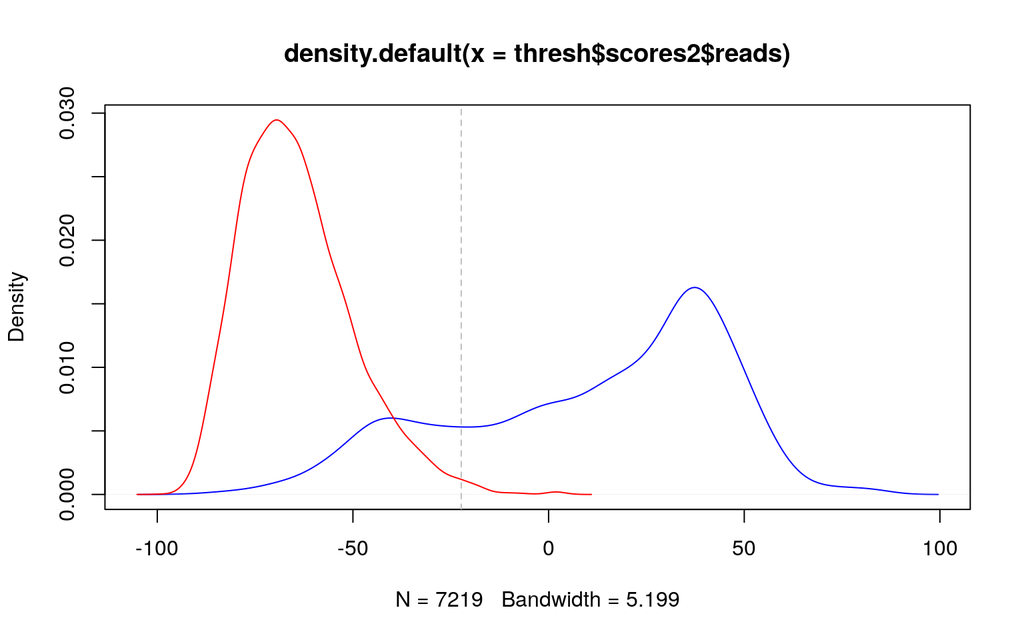

Figure 2: Distribution of adaptor 2 alignment scores for the real reads (blue) and scrambled sequences (red).

```r
real.dist <- density(thresh$scores2$reads)
scrambled.dist <- density(thresh$scores2$scrambled)
plot(real.dist, xlim=range(real.dist$x, scrambled.dist$x),
    ylim=range(real.dist$y, scrambled.dist$y), col="blue")
lines(scrambled.dist, col="red")
abline(v=thresh$threshold2, col="grey", lty=2)
```

Based on these thresholds, we retain only those reads that have well-aligned adaptors on both sides.

```r
filtered <- filterReads(aln.out, thresh$threshold1, thresh$threshold2)
nrow(filtered)
```

```
## [1] 5061
```

# 5 Demultiplexing reads

We assign reads back to the sample of origin by aligning the barcode in the adaptor against the list of reference barcode.

As with `adaptorAlign`, this can be further sped up by parallelising jobs using the `BiocParallel` package with the appropriate backend supplied to the optional `BPPARAM=` argument.

```r
debarcoded <- barcodeAlign(filtered$adaptor1$subseq$Sub1, all.barcodes, gapOpening=8, gapExtension=3, BPPARAM=multicoreParam)
debarcoded
```

```
## DataFrame with 5061 rows and 3 columns
##        barcode            score              gap
##      <integer>        <numeric>        <numeric>
## 1           40 47.9444490401652 84.1001090877088
## 2           40 47.9977522907451 94.0768198200329
## 3           45 47.9346466891747 105.963610394045
## 4            3 34.3443088066735 92.9778090561065
## 5           19 47.8706946316044  114.05535964825
## ...        ...              ...              ...
## 5057         3 44.7322471537687  77.800711831756
## 5058        11 30.2511490525068 58.8429211178905
## 5059         8  13.327013608634 56.0694655027068
## 5060        94 47.6029857104832 97.9210121690854
## 5061        80 47.9460904055689 86.0925957706004
```

We define a suitable threshold for both of these metrics with `getBarcodeThresholds`:

```r
(barcode.thresh <- getBarcodeThresholds(debarcoded))
```

```
##     score       gap
## -11.32782 -26.47951
```

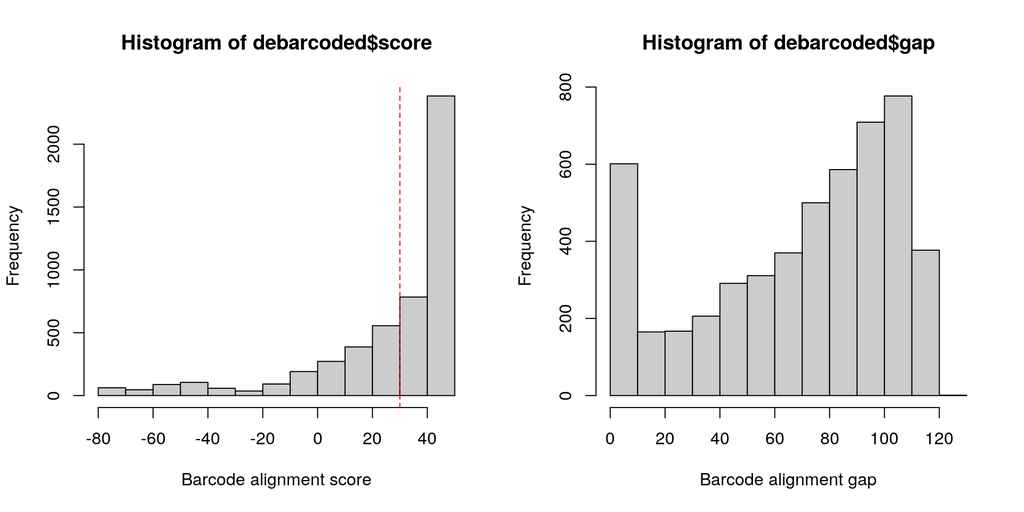

Figure 3: Distribution of barcode alignment scores and gaps.

```r
par(mfrow=c(1,2))
hist(debarcoded$score, xlab="Barcode alignment score", col="grey80")
abline(v=30, col="red", lty=2)
hist(debarcoded$gap, xlab="Barcode alignment gap", col="grey80")
abline(v=barcode.thresh["gap"], col="red", lty=2)
```

We then filter the reads to only retain those that were unambiguously assigned to a barcode:

```r
was.assigned <- debarcoded$score > 30 & debarcoded$gap > barcode.thresh["gap"]
table(debarcoded$barcode, was.assigned)
```

```
##     was.assigned
##      FALSE TRUE
##   1     53    5
##   2     28   21
##   3     58   79
##   4     20   23
##   5     22   35
##   6     15   32
##   7     19   49
##   8     18   45
##   9     12   25
##   10    17   25
##   11    42  113
##   12     5    0
##   13    29   14
```

[output cut: 82 more lines]

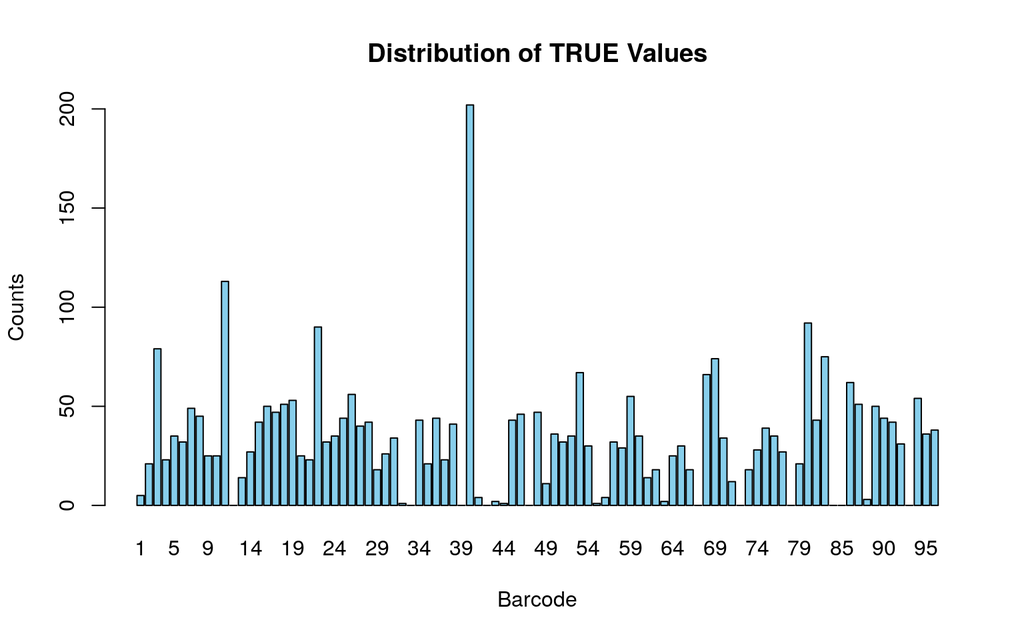

```r
# plot TRUE
true_counts <- table(debarcoded$barcode, was.assigned)[, "TRUE"]
barplot(true_counts,
        main = "Distribution of TRUE Values",
        xlab = "Barcode",
        ylab = "Counts",
        col = "skyblue")
```

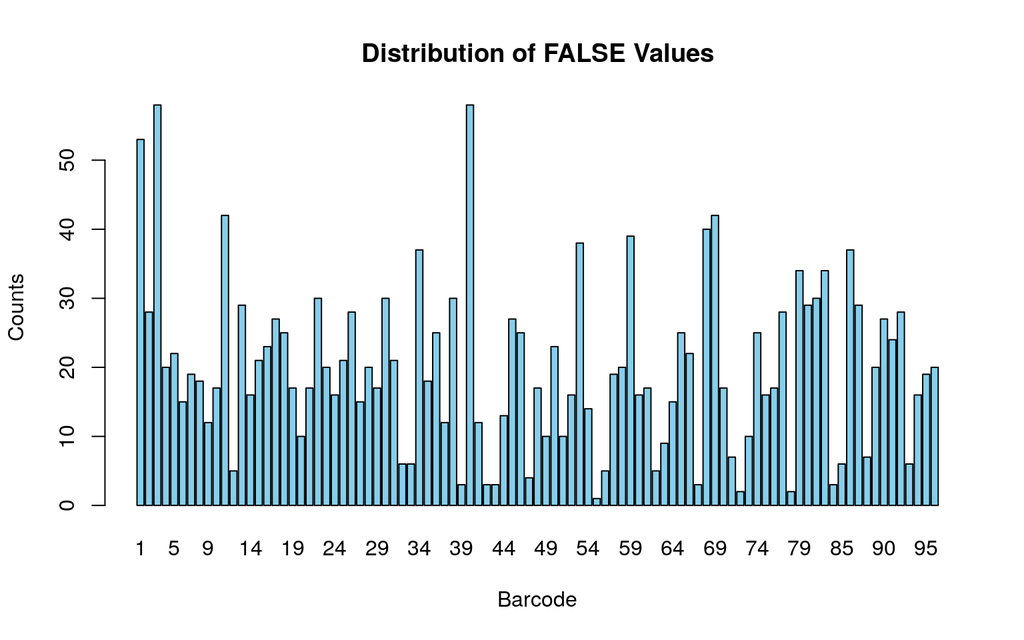

```r
# plot false
false_counts <- table(debarcoded$barcode, was.assigned)[, "FALSE"]
barplot(false_counts,
        main = "Distribution of FALSE Values",
        xlab = "Barcode",
        ylab = "Counts",
        col = "skyblue")
```

… and split them into their samples of origin:

```r
by.sample <- split(filtered[was.assigned,], debarcoded$barcode[was.assigned])
names(by.sample)
```

```
##  [1] "1"  "2"  "3"  "4"  "5"  "6"  "7"  "8"  "9"  "10" "11" "13" "14" "15"
## [15] "16" "17" "18" "19" "20" "21" "22" "23" "24" "25" "26" "27" "28" "29"
## [29] "30" "31" "32" "34" "35" "36" "37" "38" "40" "41" "43" "44" "45" "46"
## [43] "48" "49" "50" "51" "52" "53" "54" "55" "56" "57" "58" "59" "60" "61"
## [57] "62" "63" "64" "65" "66" "68" "69" "70" "71" "73" "74" "75" "76" "77"
## [71] "79" "80" "81" "82" "86" "87" "88" "89" "90" "91" "92" "94" "95" "96"
```

# 6 Writing out demultiplexed reads

We now output the demultiplexed reads by sample as a FASTQ file for the alignment step and an rds file containing the adaptor alignment information for use in grouping and error correction/deduplication.

```r
for (i in names(by.sample)) {
  my.sample <- by.sample[[i]]
  fastq.sample <- realizeReads(my.sample)
  outfile <- paste0("barcode_", i, ".fastq")
  writeXStringSet(fastq.sample, outfile, format = "fastq", qualities=quality(fastq.sample))
  saveRDS(my.sample, file = paste0("barcode_", i, ".fastq.rds"))
}
```